# South Pacific invasive alien species gap analysis in DNA barcode reference libraries

## Introduction

The goal of this analysis is to find out if there are any gaps in sequence reference databases for species that are of interest to the PacMAN project.

This notebook makes use of the caspr package, which is a set of R functions created to support data analysis within the PacMAN project.

## WRiMS gap analysis

### Creating a species list

Before getting into priority species lists and regional checklists, let’s first perform a gap analysis for the entire WRiMS checklist. First create a list of accepted species names based on the WRiMS dataset in GBIF:

```r
library(caspr)

cl_wrims <- wrims_checklist()
```

This gives us a checklist with **2263** species from **28** phyla.

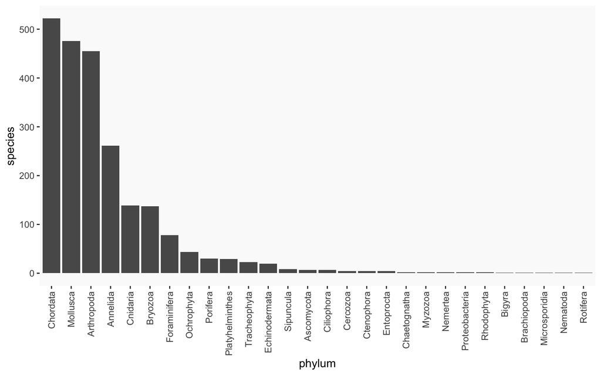

```r
library(ggplot2)
library(dplyr)

phylum_stats <- cl_wrims %>%
  group_by(phylum) %>%
  summarize(species = n()) %>%
  arrange(desc(species))

th <- theme(
  panel.background = element_rect(fill = "#fafafa"),
  panel.grid.major = element_blank(),
  panel.grid.minor = element_blank()
)

ggplot() +
  geom_histogram(data = phylum_stats, aes(x = reorder(phylum, -species), y = species), stat = "identity") +
  xlab("phylum") +
  theme(axis.text.x = element_text(angle = 90, vjust = 0.5, hjust = 1)) +
  th
```

### Checking BOLD for sequences

In this first implementation we are querying BOLD by taxon name and not by identifier. Let’s get the number of sequences in BOLD by species and marker:

```r
library(bold)
library(purrr)
library(progress)

if (file.exists("df_bold_wrims.rds")) {
  df_bold_wrims <- readRDS("df_bold_wrims.rds")
} else {
  bold_list <- sapply(cl_wrims$scientificName, function(x) NULL)
  pb <- progress_estimated(nrow(cl_wrims))
  for (i in 1:length(cl_wrims$scientificName)) {
    if (is.null(bold_list[[i]])) {
      taxon <- cl_wrims$scientificName[i]
      bold_list[[i]] <- caspr::bold_statistics(taxon)
    }
    pb$tick()$print()
  }
  df_bold_wrims <- bind_rows(bold_list, .id = "scientificName")
  saveRDS(df_bold_wrims, "df_bold_wrims.rds")
}
```

This results us a table with **43** distinct marker codes for **1182** species. This is an overview of the most common markers:

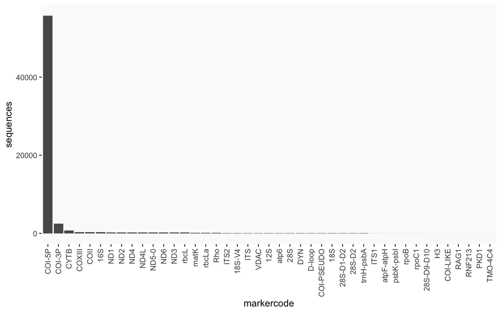

```r
library(knitr)

marker_stats <- df_bold_wrims %>%
  group_by(markercode) %>%
  summarize(sequences = sum(sequences), species = length(unique(scientificName))) %>%
  arrange(-sequences)

ggplot() +
  geom_histogram(data = marker_stats, aes(x = reorder(markercode, -sequences), y = sequences), stat = "identity") +
  theme(axis.text.x = element_text(angle = 90, vjust = 0.5, hjust = 1)) +
  xlab("markercode") +
  th
```

```r
marker_stats %>%
  slice_head(n = 20) %>%
  kable()
```

| markercode | sequences | species |
| --- | --- | --- |
| COI-5P | 55752 | 1133 |
| COI-3P | 2492 | 114 |
| CYTB | 709 | 249 |
| COXIII | 341 | 237 |
| COII | 332 | 228 |
| 16S | 328 | 63 |
| ND1 | 248 | 237 |
| ND2 | 248 | 237 |
| ND4 | 248 | 237 |
| ND4L | 248 | 237 |
| ND5-0 | 248 | 237 |
| ND6 | 248 | 237 |
| ND3 | 247 | 236 |
| rbcL | 211 | 33 |
| matK | 156 | 15 |
| rbcLa | 142 | 17 |
| Rho | 126 | 29 |
| ITS2 | 102 | 17 |
| 18S-V4 | 101 | 2 |
| ITS | 99 | 14 |

### Gap analysis

Let’s now figure out which fraction of species have any of the desired sequences. For this analysis I’m only including the following markers: COI, 18S, rbcL, matK [^1].

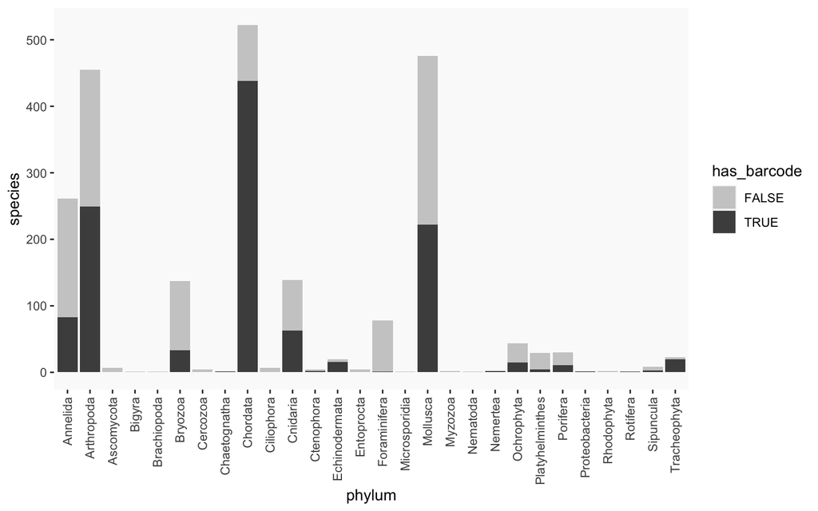

```r
selected_markers <- c("COI-5P", "18S", "rbcL", "rbcLa", "matK")

wrims_species_stats <- df_bold_wrims %>%
  filter(markercode %in% selected_markers) %>%
  full_join(cl_wrims, by = "scientificName") %>%
  group_by(phylum, scientificName) %>%
  summarize(
    has_barcode = as.logical(sum(!is.na(markercode))),
    markers = length(unique(markercode)),
    sequences = sum(sequences)
  )

wrims_phylum_stats <- wrims_species_stats %>%
  group_by(phylum, has_barcode) %>%
  summarize(species = n())

ggplot() +
  geom_histogram(data = wrims_phylum_stats, aes(x = phylum, y = species, fill = has_barcode), stat = "identity") +
  scale_fill_grey(start = 0.8, end = 0.3) +
  theme(axis.text.x = element_text(angle = 90, vjust = 0.5, hjust = 1)) +
  th
```

In conclusion, of the **2263** WRiMS species, **1165** have one of the desired barcodes.

## Priority lists gap analysis

### Creating a species list

We can now repeat the analysis for the priority lists. The `caspr` package includes a function to fetch the priority lists from Google Sheets.

```r
cl_priority <- expert_checklists() %>%
  filter(taxonRank == "species")
```

So far, we have been able to match **205** taxa from the priority lists to WoRMS species.

Before we proceed, let’s check how many species from the priority lists are present in WRiMS. I expected all species to be there, but that’s not the case. The following species are not in WRiMS:

```r
cl_priority %>%
  filter(!(taxonID %in% cl_wrims$taxonID)) %>%
  select(taxonID, scientificName, references) %>%
  kable()
```

| taxonID | scientificName | references |
| --- | --- | --- |
| 102401 | Ericthonius brasiliensis | Guam potential invasive; Tropical West Pacific introduced |
| 102805 | Elasmopus rapax | Tropical West Pacific introduced |
| 103175 | Stenothoe valida | Tropical West Pacific introduced |
| 103843 | Microcosmus pupa | Tropical West Pacific introduced |
| 117372 | Clytia noliformis | Tropical West Pacific introduced |
| 117433 | Corydendrium parasiticum | Tropical West Pacific introduced |
| 117440 | Turritopsis nutricula | Tropical West Pacific introduced |
| 126983 | Mugil cephalus | Tropical West Pacific introduced |
| 129914 | Chaetopterus variopedatus | Tropical West Pacific introduced |
| 130451 | Oenone fulgida | Tropical West Pacific introduced |
| 131051 | Serpula vermicularis | Guam potential invasive; Tropical West Pacific introduced |
| 131544 | Thelepus setosus | Tropical West Pacific introduced |
| 132304 | Darwinella australiensis | Guam potential invasive |
| 140103 | Hiatella arctica | Tropical West Pacific introduced |
| 145634 | Hypnea musciformis | Hawaiian most impactful |
| 145721 | Undaria pinnatifida | Australian Priority list |
| 164455 | Heteropia glomerosa | Guam potential invasive |
| 164869 | Chelonaplysilla violacea | Guam potential invasive |
| 164893 | Dictyodendrilla dendyi | Guam potential invasive |
| 164922 | Dysidea arenaria | Guam potential invasive |
| 165135 | Ianthella basta | Tropical West Pacific introduced |
| 166302 | Cladocroce burapha | Guam potential invasive |
| 167963 | Echinodictyum asperum | Guam potential invasive |
| 168632 | Mycale (Mycale) grandis | Guam potential invasive |
| 168990 | Lissodendoryx (Lissodendoryx) similis | Guam potential invasive |
| 169023 | Monanchora quadrangulata | Guam potential invasive |
| 169088 | Crella (Yvesia) spinulata | Guam potential invasive |
| 169308 | Phorbas arborescens | Guam potential invasive |
| 169544 | Strongylamma wilsoni | Guam potential invasive |
| 169585 | Tedania (Tedania) strongylostyla | Guam potential invasive |

[output cut: 62 more lines]

This means we cannot just subset the results of our previous gap analysis, so let’s start over.

### Checking BOLD for sequences

```r
if (file.exists("df_bold_priority.rds")) {
  df_bold_priority <- readRDS("df_bold_priority.rds")
} else {
  bold_list <- sapply(cl_priority$scientificName, function(x) NULL)
  pb <- progress_estimated(nrow(cl_priority))
  for (i in 1:length(cl_priority$scientificName)) {
    if (is.null(bold_list[[i]])) {
      taxon <- cl_priority$scientificName[i]
      bold_list[[i]] <- caspr::bold_statistics(taxon)
    }
    pb$tick()$print()
  }
  df_bold_priority <- bind_rows(bold_list, .id = "scientificName")
  saveRDS(df_bold_priority, "df_bold_priority.rds")
}
```

### Gap analysis

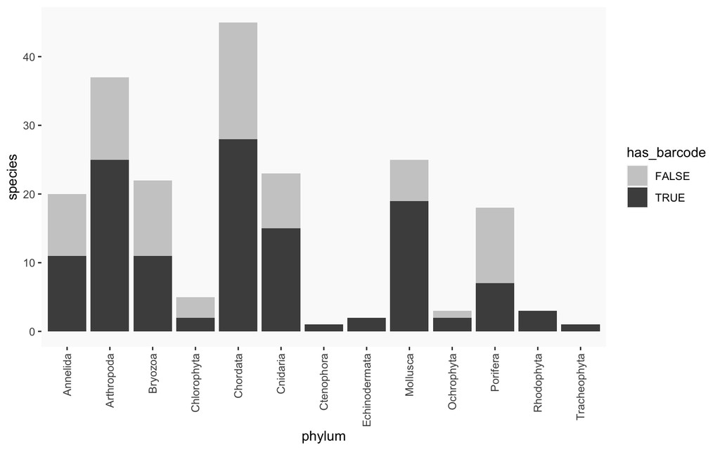

```r
priority_species_stats <- df_bold_priority %>%
  filter(markercode %in% selected_markers) %>%
  full_join(cl_priority, by = "scientificName") %>%
  group_by(phylum, scientificName) %>%
  summarize(
    has_barcode = as.logical(sum(!is.na(markercode))),
    markers = length(unique(markercode)),
    sequences = sum(sequences)
  )

priority_phylum_stats <- priority_species_stats %>%
  group_by(phylum, has_barcode) %>%
  summarize(species = n())

ggplot() +
  geom_histogram(data = priority_phylum_stats, aes(x = phylum, y = species, fill = has_barcode), stat = "identity") +
  scale_fill_grey(start = 0.8, end = 0.3) +
  theme(axis.text.x = element_text(angle = 90, vjust = 0.5, hjust = 1)) +
  th
```

In conclusion, of the **205** priority species, **127** have one of the desired barcodes.

## South Pacific gap analysis

### Region of interest

```r
library(sf)
library(dplyr)
library(leaflet)
library(caspr)

leaflet() %>%
  addProviderTiles("CartoDB.Positron") %>%
  addPolygons(data = st_as_sfc(wkt_south_pacific, crs = 4326), color = "#ff9900")
```

[interactive chart not shown]

To do.

## Issues to be resolved

- limit checklist to species introduced in the region
- query BOLD by taxon ID if available
- NCBI
- create priority list for barcoding specimens
[^1]: Duarte S, Vieira PE, Costa FO (2020) Assessment of species gaps in DNA barcode libraries of non-indigenous species (NIS) occurring in European coastal regions. Metabarcoding and Metagenomics 4: e55162. https://doi.org/10.3897/mbmg.4.55162